### 1. Fast Food

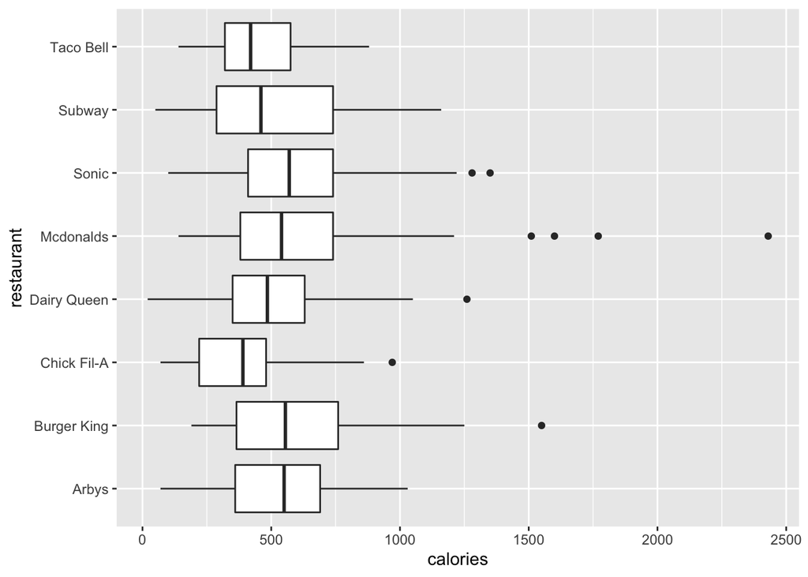

```r
fastfood <- openintro::fastfood
ggplot(fastfood,aes(restaurant,calories))+geom_boxplot()+coord_flip()
```

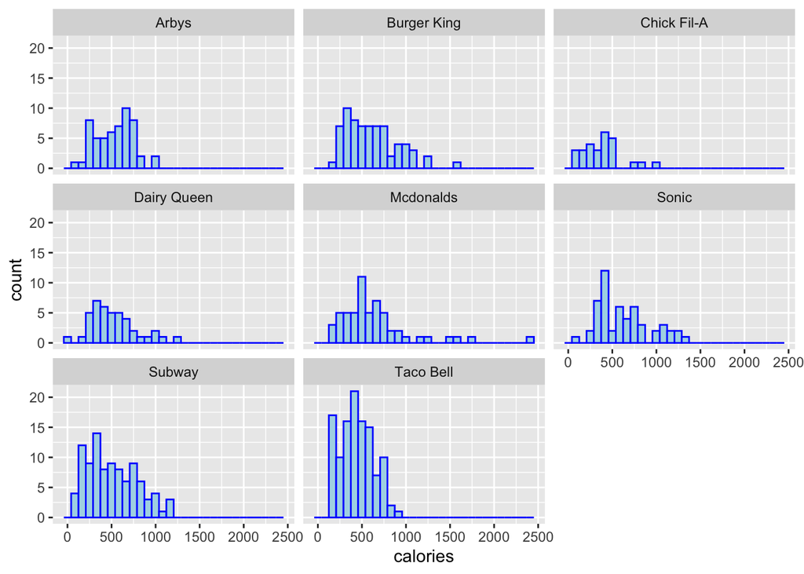

```r
ggplot(fastfood,aes(calories))+geom_histogram( color = "blue", fill = "lightblue")+
  facet_wrap(~ restaurant)
```

Short Answer: compared with boxplot, it’s easier to find the mean and mode of the data from the histogram because diagrammatic representation of histogram gives the outlook of data which allows viewers to compare data and analyze it.

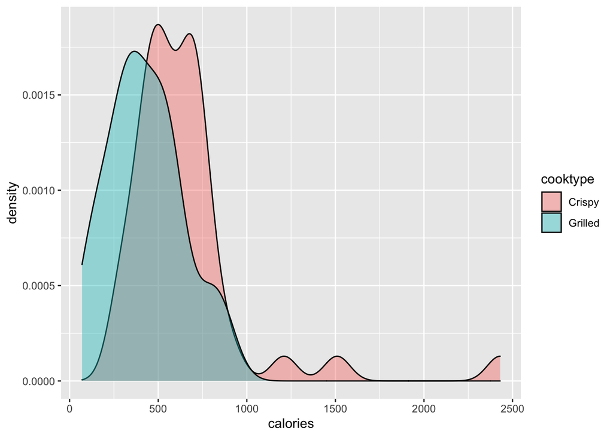

```r
new_data <- filter(fastfood,
       xor(str_detect(fastfood$item,'Crispy'),str_detect(fastfood$item,'Grilled'))==TRUE)
new_data$cooktype <-
  ifelse(str_detect(new_data$item,'Crispy')==TRUE,'Crispy','Grilled')
ggplot(new_data,aes(x=calories,fill=cooktype))+geom_density(alpha=.4)
```

Short Answer: Baesd on the graph, crispy food has more calories than grilled food. Most grilled food has calories less than 500 and most crispy food has calories more than 500 and there are some crispy food have extremely high calories. When randonmly choosing a food, it’s more likely to choose the food that has the calories between 250 and 750.

### 2. Temporal Lobes

```r
mtl <- openintro::mtl
# computer the number of class
nclass.Sturges(mtl$asubic)
```

```
## [1] 7
```

```r
ceiling(log(length(mtl$asubic),base=2))+1
```

```
## [1] 7
```

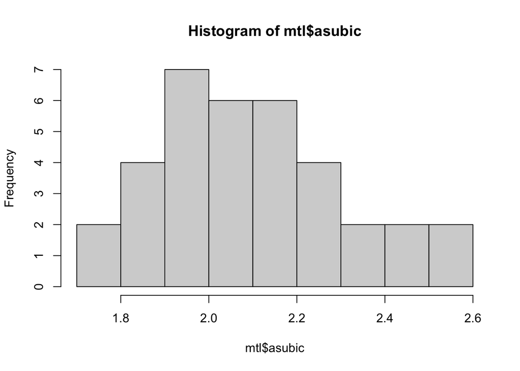

```r
hist(mtl$asubic,breaks="Sturges")
```

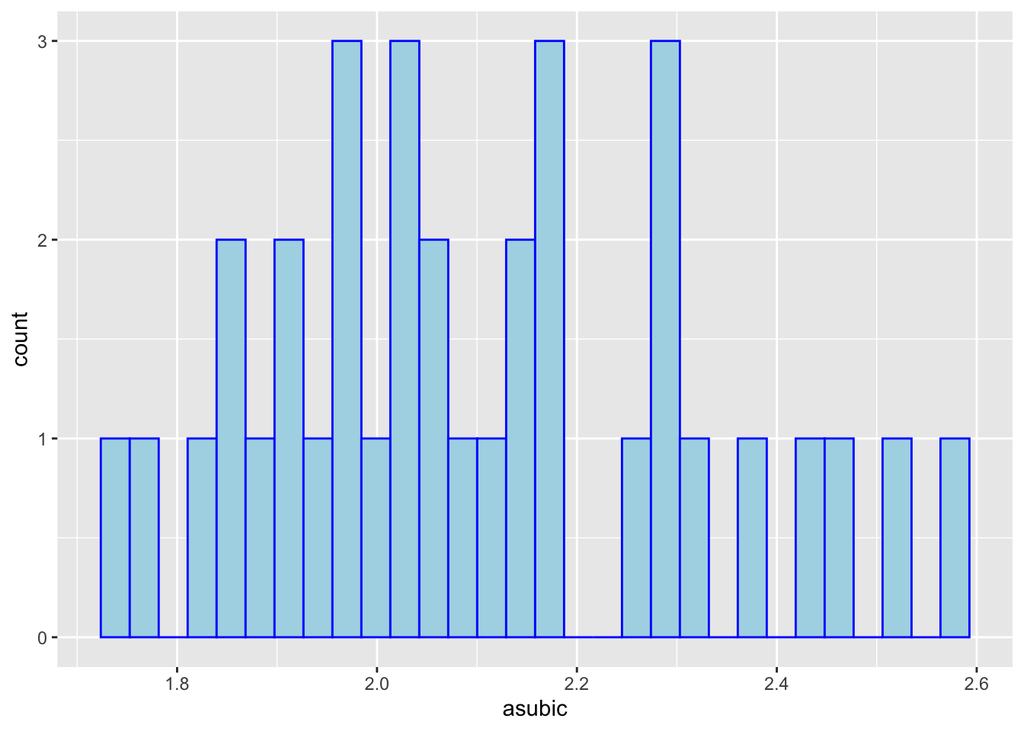

```r
ggplot(mtl,aes(asubic))+geom_histogram( color = "blue", fill = "lightblue")
```

Short Answer: The default method base R uses to determine the bin number is use Sturges’formula. The calculation is above. The default bin number for ggplot is 30. I think the ggplot-small bin width is the better choice for the dataset. Asubic represents the thickness of the subiculum subregion, in order to better understand the relationship between sedentary behavior and asubic, we need the data to be as detailed as possible. Small bin width means more details and it can help visualize the how the difference in asubic affect the sedentary behavior and the histogram with small bin width is more clear and detailed than the one with big bin width. I think large bin width is better because it can easily show the underlying pattern (frequency distribution) of the data. If the bin width is too small, it only shows the individual data. b)

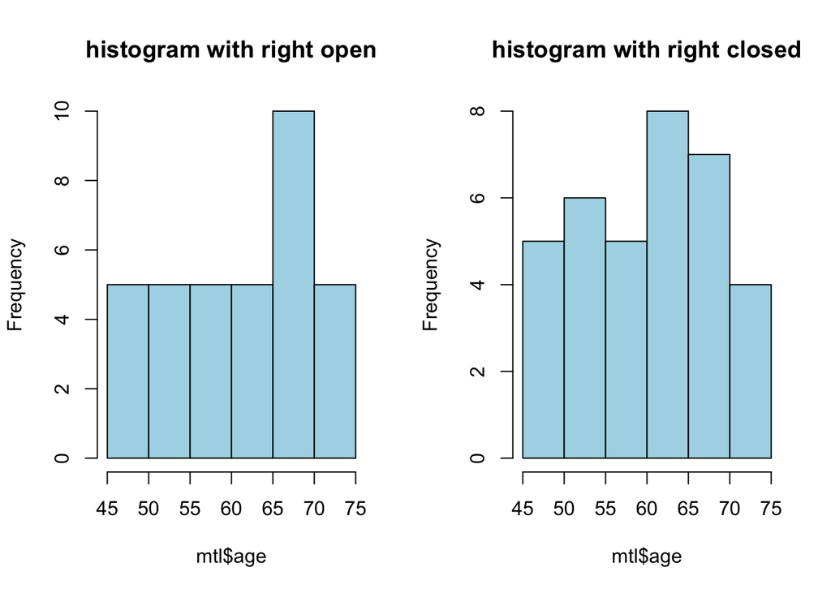

```r
par(mfrow=c(1,2))
h1 <- hist(mtl$age,right = FALSE, col = "lightblue",main='histogram with right open')
h2 <- hist(mtl$age,right = TRUE, col = "lightblue",main='histogram with right closed')
```

c)

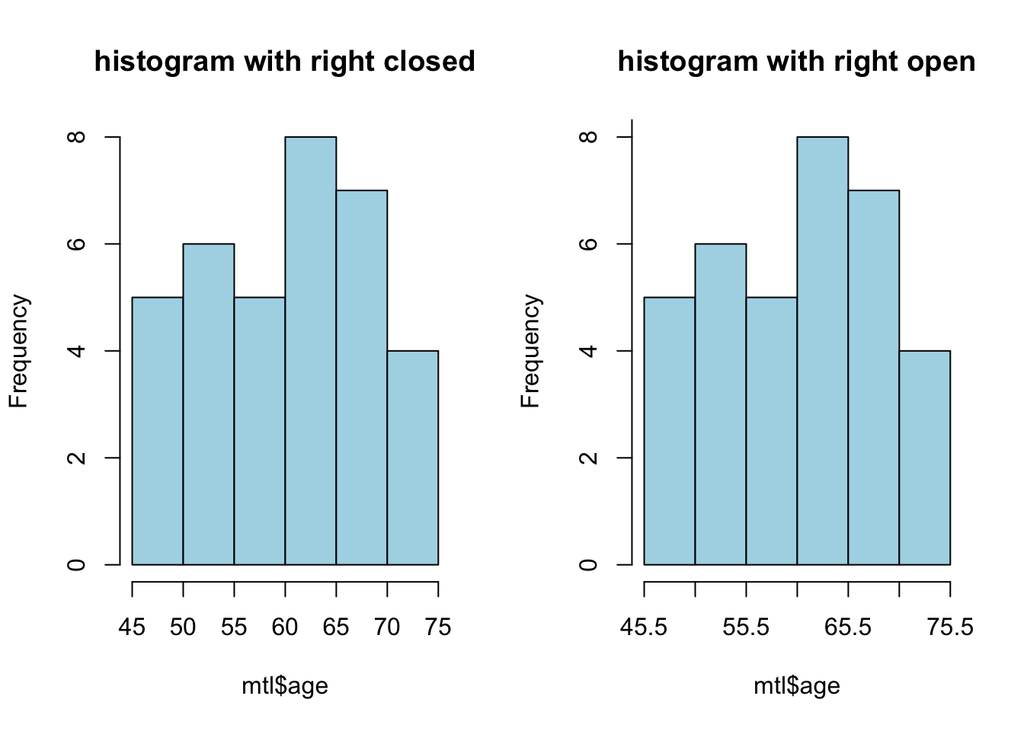

```r
par(mfrow=c(1,2))
h2 <- hist(mtl$age,right = TRUE, col = "lightblue",main='histogram with right closed')
hist(mtl$age,right = FALSE, col = "lightblue",breaks = seq(45.5,75.5,5),axes=FALSE,
     main='histogram with right open')
axis(1,at=seq(45.5,75.5,5))
axis(2,at=seq(0,10,2))
```

Short Answer: To make the two histograms identical, the strategy used here is to change the histogram with right open by shifting the boundary of each bin to the right by 0.5, so that the data previously not included will be included now and each bin will contain the same data and graph will be identical.

### 3. Soybeans

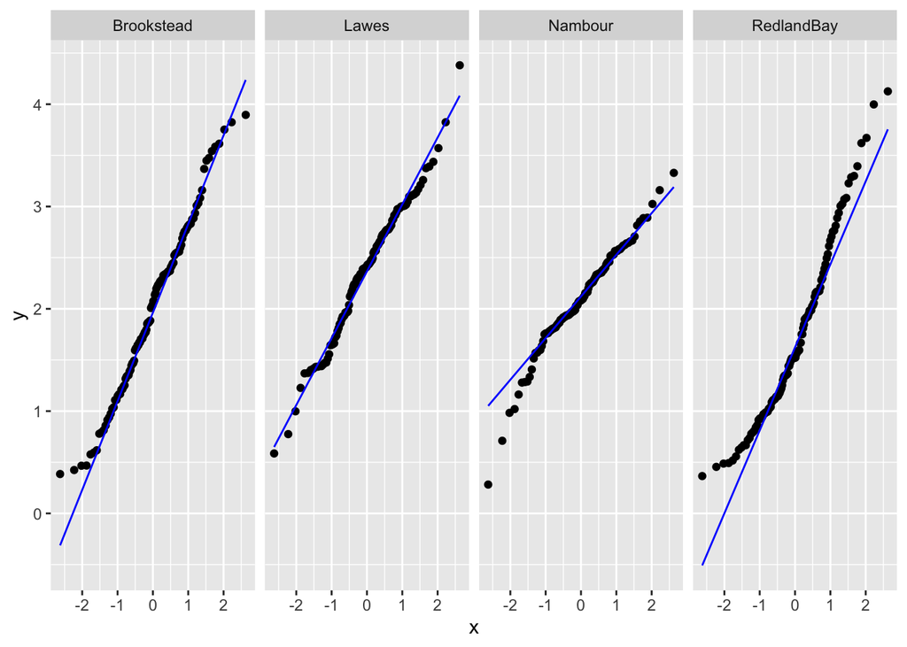

```r
ggplot(australia.soybean, aes(sample=yield)) + geom_qq(distribution = qnorm) +
  geom_qq_line(col = "blue")+
  facet_wrap(~ loc, nrow = 1)
```

Short Answer: Based on the graph, location Lawes appears to be closest to a normal distribution.

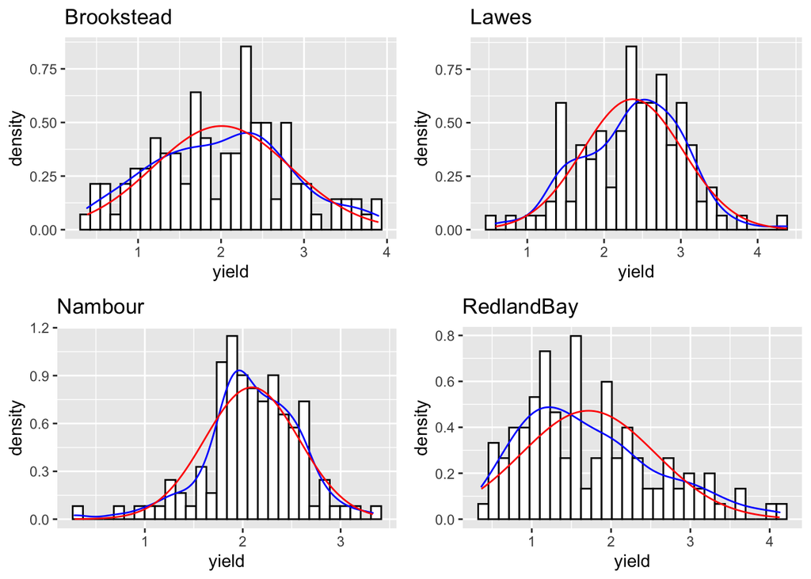

```r
Brookstead <- filter(australia.soybean,loc=='Brookstead')
Lawes <- filter(australia.soybean,loc=='Lawes')
Nambour <- filter(australia.soybean,loc=='Nambour')
RedlandBay <- filter(australia.soybean,loc=='RedlandBay')

g1 <- ggplot(Brookstead,aes(yield))+
  geom_histogram(aes(y=..density..),color = "black", fill = "white")+
  geom_density(col='blue')+
  stat_function(fun = dnorm,
                args = list(mean = mean(Brookstead$yield),
                            sd = sd(Brookstead$yield)),col='red')+
  ggtitle("Brookstead")
g2 <- ggplot(Lawes,aes(yield))+
  geom_histogram(aes(y=..density..),color = "black", fill = "white")+
  geom_density(col='blue')+
  stat_function(fun = dnorm,
                args = list(mean = mean(Lawes$yield),
                            sd = sd(Lawes$yield)),col='red')+
  ggtitle("Lawes")
g3 <- ggplot(Nambour,aes(yield))+
  geom_histogram(aes(y=..density..),color = "black", fill = "white")+
  geom_density(col='blue')+
  stat_function(fun = dnorm,
                args = list(mean = mean(Nambour$yield),
                            sd = sd(Nambour$yield)),col='red')+
  ggtitle("Nambour")
g4 <- ggplot(RedlandBay,aes(yield))+
  geom_histogram(aes(y=..density..),color = "black", fill = "white")+
  geom_density(col='blue')+
  stat_function(fun = dnorm,
                args = list(mean = mean(RedlandBay$yield),
                            sd = sd(RedlandBay$yield)),col='red')+
  ggtitle("RedlandBay")
grid.arrange(g1,g2,g3,g4,nrow=2)
```

c)

```r
B <- shapiro.test(Brookstead$yield)
L <- shapiro.test(Lawes$yield)
N <- shapiro.test(Nambour$yield)
R <- shapiro.test(RedlandBay$yield)
B
```

```
##
##  Shapiro-Wilk normality test
##
## data:  Brookstead$yield
## W = 0.98573, p-value = 0.2594
```

```r
L
```

```
##
##  Shapiro-Wilk normality test
##
## data:  Lawes$yield
## W = 0.98695, p-value = 0.3279
```

```r
N
```

```
##
##  Shapiro-Wilk normality test
##
## data:  Nambour$yield
## W = 0.97299, p-value = 0.01911
```

```r
R
```

```
##
##  Shapiro-Wilk normality test
##
## data:  RedlandBay$yield
## W = 0.95228, p-value = 0.0004117
```

Short Answer: The null-hypothesis of this test is that the population is normally distributed.If the p value is less than the chosen alpha level, then the null hypothesis is rejected and there is evidence that the data tested are not normally distributed. If the p value is greater than the chosen alpha level, then the null hypothesis can not be rejected. For test on Brookstead, the p-value(0.2594) is greater than the alpha(0.05), so we cannnot reject the null hypothesis and conclude that yield of Brookstead is normally distributed. For test on Lawes, the p-value(0.3279) is greater than the alpha(0.05), so we cannnot reject the null hypothesis and conclude that yield of lawes is normally distributed. For test on Nambour, the p-value(0.01911) is less than the alpha(0.05), so we reject the null hypothesis and there is evidence that the yield of Nambour is not normally distributed. For test on RedlandBay, the p-value(0.0004117) is less than the alpha(0.05), so we reject the null hypothesis and there is evidence that the yield of RedlandBay is not normally distributed.

Short Answer: The three methods used in a,b and c almost give the same results. In part(a), we used the qqplot with theoretical normal lines, from the graph we conclude that location Lawes appears to be closest the a normal distribution. In part(b), we plotted density histograms with density curves and theoretical normal curves and the graph shows that Lawes and Brookstead appear to be normally distributed. In part(c), we performed the Shapiro-Wilk tests and the test results show that Lawes and Brookstead are normally distributed.

### 4. Doctors

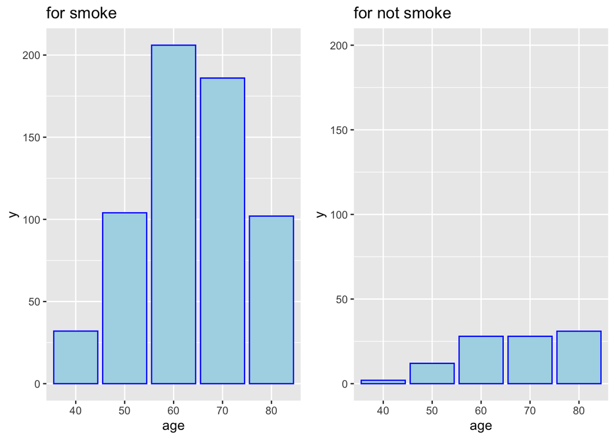

```r
smoke <- filter(breslow,smoke==1)
nsmoke <- filter(breslow,smoke==0)
g1 <- ggplot(smoke,aes(age,y))+geom_col(color = "blue", fill = "lightblue")+
  ggtitle("for smoke")
g2 <- ggplot(nsmoke,aes(age,y))+geom_col(color = "blue", fill = "lightblue")+
  scale_y_continuous(limits=c(0, 200))+
  ggtitle("for not smoke")
grid.arrange(g1,g2,nrow=1)
```

### 5. Loans a)

```r
str(loans_full_schema$loan_amount)
```

```
##  int [1:10000] 28000 5000 2000 21600 23000 5000 24000 20000 20000 6400 ...
```

```r
summary(loans_full_schema$loan_amount)
```

```
##    Min. 1st Qu.  Median    Mean 3rd Qu.    Max.
##    1000    8000   14500   16362   24000   40000
```

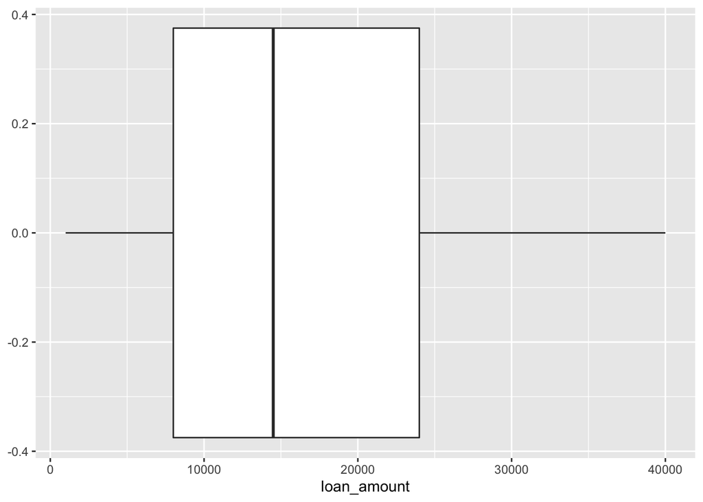

```r
ggplot(loans_full_schema,aes(loan_amount))+geom_boxplot()
```

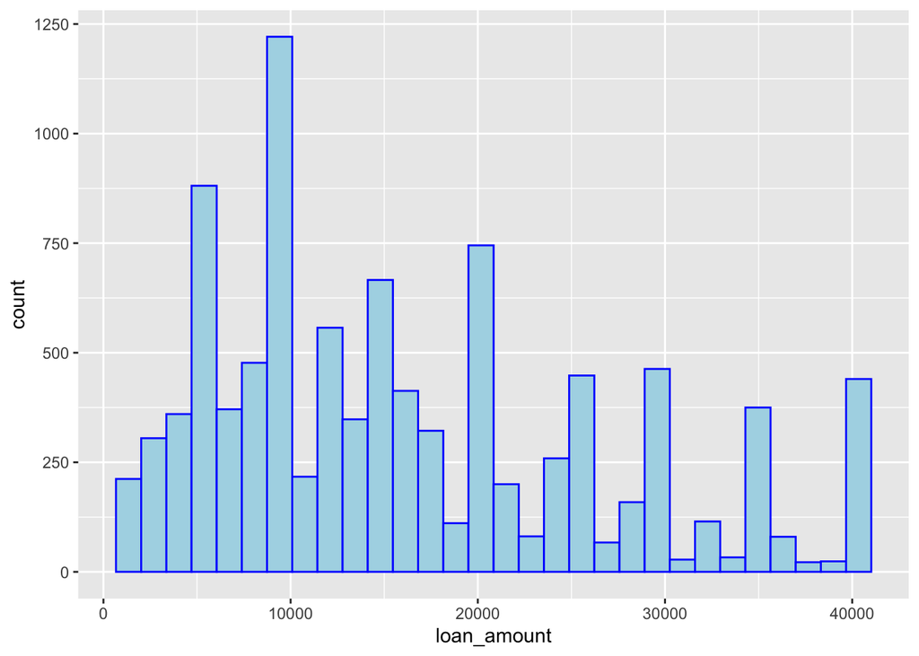

```r
ggplot(loans_full_schema,aes(loan_amount))+geom_histogram(color = "blue", fill = "lightblue")
```

b)

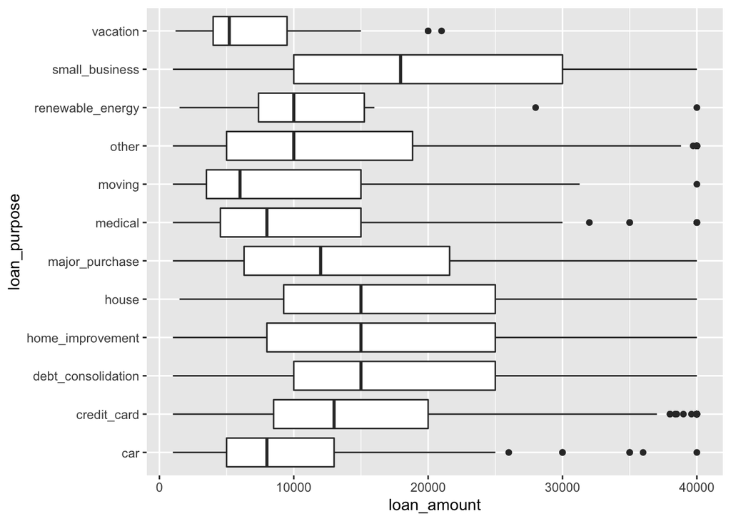

```r
ggplot(loans_full_schema,aes(x=loan_amount,y=loan_purpose))+
  geom_boxplot()
```

c)

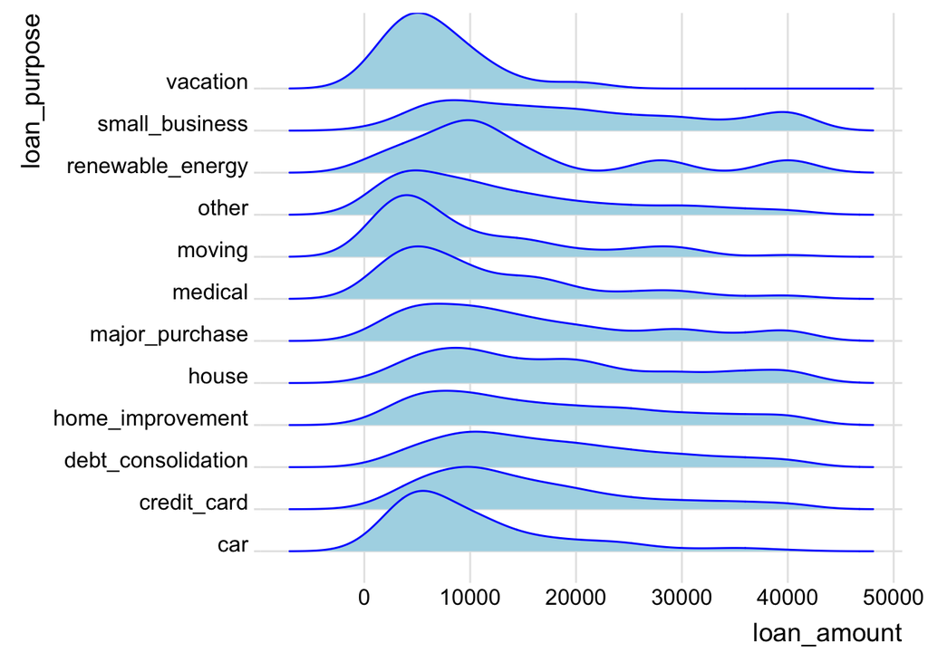

```r
ggplot(loans_full_schema,aes(x=loan_amount,y=loan_purpose))+
  geom_density_ridges(color = "blue", fill = "lightblue") +
  theme_ridges()
```

d) Short Answer:I think boxplot is more effective for this dataset because it gives a clear summary of the data such as median, range and outliers and it provides some indication of the data’s symmetry and skew-ness. it’s easier to visualize distribution of loan amount the and compare the data for each loan purpose. Using ridgeline plot is not a good choice for hit dataset because overlap in the plot can obscure underlying patterns.